# Miscelaneous

Jan-Philipp Kolb

07/27/2015

## Requested Expert Knowledge

- Predictive Analytics
- [Segmentation methods](http://www.forecastingprinciples.com/files/LRF-Ch9b.pdf) [in image processing](http://www.cs.uu.nl/docs/vakken/ibv/reader/chapter10.pdf)
- Key Perfomrance Indicator (KPI)

## [Data science](http://www.r-bloggers.com/oreilly-data-scientist-salary-and-tools-survey-november-2014/)

[Applications for data science](http://www.analyticsvidhya.com/blog/2015/09/applications-data-science/)

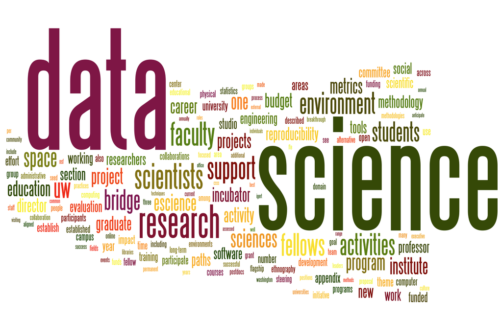

## Way to become a data scientis

[Six steps before pursuing education data science](http://www.datascienceweekly.org/blog/26-six-steps-to-take-before-pursuing-education-to-get-a-data-science-job)

[figure not shown]

Metromap Data Science

[figure not shown]

## Become-a-Computer-Scientist

- [Data scientist but where](http://ibmexperts.computerwoche.de/analytics-big-data/artikel/data-scientist-werden-aber-wo)
- Become-a-Computer-Scientist
- [Coursera specializations](http://www.r-bloggers.com/coursera-specializations-data-science-systems-biology-python-programming/)

## Videos on data science

[figure not shown]

[figure not shown]

[figure not shown]

[figure not shown]

## Writing R-packages

- [Packages in Rstudio](http://www.r-bloggers.com/smart-hackathon-day-2-writing-packages-in-rstudio/)
- [Overview R-packages](http://www.rstudio.com/ide/docs/packages/overview)

## Where to publish research

- [In which journals should I publish my software?](http://www.software.ac.uk/resources/guides/which-journals-should-i-publish-my-software)
- [List of journals](http://www.jammuuniversity.in/journals/statistics-journals.htm)
- [journal list](http://www.statsci.org/jourlist.html)

Journals:

- [J-reading](http://www.j-reading.org/index.php/geography)
- [Social Science Computer Review](http://ssc.sagepub.com/)
- [Computational Statistics and Data Analysis](http://www.journals.elsevier.com/computational-statistics-and-data-analysis/)
- [Guide for authors](http://www.elsevier.com/journals/computational-statistics-and-data-analysis/0167-9473/guide-for-authors)
- [style file](http://www.ctan.org/pkg/elsarticle)
- [What is important](http://www.elsevier.com/connect/8-reasons-i-accepted-your-article)
- [Where to publish R research](https://www.researchgate.net/post/What_is_the_best_peer-reviewed_place_to_publish_an_R_package)
- [plosone](http://journals.plos.org/plosone/)
- [Insights from the field](http://surveyinsights.org/)

## Interesting Papers

[Impact factors](http://www.scimagojr.com/journalrank.php?category=3312)

[Journal of applied social science](http://jax.sagepub.com/)

- [example on georeferencing](http://jax.sagepub.com/content/os-21/1/10.full.pdf+html)

[Political Geography](http://www.journals.elsevier.com/political-geography/)

[European Sociological Review](http://esr.oxfordjournals.org/)

[Oxford Review of Education](http://www.tandfonline.com/toc/core20/current)

[Research in Social Stratification and Mobility](http://www.journals.elsevier.com/research-in-social-stratification-and-mobility/)

[Survey Research Methods](https://ojs.ub.uni-konstanz.de/srm/)

## Economic Journals

[Journal of Economic Geography](http://www.oxfordjournals.org/our_journals/jnlecg/for_authors/index.html)

## Misc on publishing

[Discussion on impact factor](https://www.researchgate.net/post/How_to_find_ISI_journals_by_impact_factor_zero2)

[Critique on scholarly publishing](https://scholarlyoa.com/2015/01/02/bealls-list-of-predatory-publishers-2015/)

[How to get published](http://www.theguardian.com/education/2015/jan/03/how-to-get-published-in-an-academic-journal-top-tips-from-editors)

[three tips on writing](http://www.theguardian.com/higher-education-network/2014/dec/22/overcoming-writers-block-three-top-tips)

journals easy to publish

[How to find journals](https://www.quora.com/What-is-a-journal-thats-relatively-easy-to-publish-in)

[find journals](https://www.researchgate.net/post/How_to_find_ISI_journals_by_impact_factor_zero2)

## Open Source platforms

- [Intro Github](https://guides.github.com/introduction/)
- [Codeplex](https://www.codeplex.com/)
- [Bitbucket](https://bitbucket.org/)
- [Google code](https://code.google.com/)
- [sourceforge](http://sourceforge.net/)

## Java

- [JRI - Java/R Interface](http://rforge.net/JRI/index.html)

```r
system.file("jri",package="rJava")
library(rJava)
```

- [Clojure](http://clojure.org/) is a dynamic programming language that targets the Java Virtual Machine
- [R and V8/json](http://www.r-bloggers.com/doh-i-could-have-had-just-used-v8/)

## Getting to know html

- [Introduction to HTML](https://developer.mozilla.org/en-US/docs/Web/Guide/HTML/Introduction)
- [HTML Intro](http://www.w3schools.com/html/html_intro.asp)

## Further Languages

- [Comparison of R and other statistical programs](http://blog.datacamp.com/statistical-language-wars-the-infograph/)
- [Which programming language should you learn](http://www.rzbt.haw-hamburg.de/dankert/ccppjava.html/)
- [Language war](http://www.r-bloggers.com/r-beats-python-r-beats-julia-anyone-else-wanna-challenge-r/)
- [Don’t R alone! A guide to tools for collaboration with R](http://www.noamross.net/blog/2013/1/7/collaborating-with-r.html)
- [Coding ground](http://www.tutorialspoint.com/codingground.htm) - compile Rcode online

## Ruby

- [Jekyll](http://nicolewhite.github.io/r/2015/02/07/r-blogging-with-rmarkdown-knitr-jekyll.html)
- [Ruby webpage](https://www.ruby-lang.org/en/downloads/)
- [Try ruby](http://tryruby.org/levels/1/challenges/0)
- [Overpass with Ruby](http://jamescpoole.com/tag/overpass-api/)

## Links

- [Google programming language GO](https://golang.org/)
- [Go language blocks in Rmarkdown](http://datadrivensecurity.info/blog/posts/2015/Jun/running-other-languages-in-r-markdown-files/)
- [Open CPU](https://www.opencpu.org/)
- [KNIME](https://tech.knime.org/getting-started)
- [kaggle](https://www.kaggle.com/)
- [net awards](https://thenetawards.com/previous-winners/)

## Persons

- [Michael Freeman](http://mfviz.com/#/) - [stolen years](http://guns.periscopic.com/?year=2013)
- [Zach Holman](http://zachholman.com/) - [What They Don’t Tell You About Public Speaking](http://zachholman.com/posts/what-they-dont-tell-you-about-public-speaking/)

The R-Files - [Hadley Wickham](http://blog.revolutionanalytics.com/2010/09/the-r-files-hadley-wickham.html)

- [Dirk Eddelbuettel](http://datascience.la/dirk-eddelbuettel-the-user-2014-interview/)
- [Mikola Lysenko](https://www.youtube.com/watch?v=YD7iqHJ0NUI&index=14&list=PLPhU2Tz1TddCis5MZlx1HQeK5GYJoIbu8)
- [Mathew Conlen](http://www.mathisonian.com/)
- [More websites of persons](https://plotcon.plot.ly/schedule)

## Conferences

- [Overview of conferences](http://lanyrd.com/)
- [EARL conference](http://www.earl-conference.com/)
- [OpenSourceConvention](http://www.oscon.com/open-source-2015)
- [OSCON Europe](http://www.oscon.com/open-source-eu-2015)
- [GDR Ecologie Statistique](https://sites.google.com/site/gdrecostat/)
- [O’Reilly Strata Conference](http://strataconf.com/)
- [European Congress of Methodology](https://www.metheval.uni-jena.de/projekte/eam/index.php)

## Events

- [Heidelberg Unseminars in Bioinformatics](http://www.hub-hub.de/wiki/index.php?title=HUB_-_Heidelberg_Unseminars_in_Bioinformatics)
- [HUB Events](http://www.hub-hub.de/wiki/index.php?title=EventAds)

## Github Usage

- [Cloning a repo on linux](https://help.github.com/articles/cloning-a-repository/)

## Android Apps

[Java Tool to build Android Apps](https://www.jetbrains.com/idea/)

## Ideas

[Own projects](https://www.kickstarter.com/)

[OpenSTack](https://de.wikipedia.org/wiki/OpenStack)

[CRE - Cloud Computing](http://cre.fm/cre176-cloud-computing)

## Filehosting

OwnCloud

- [Software for filehosting](http://www.cyberciti.biz/cloud-computing/7-awesome-open-source-cloud-storage-software-for-your-privacy-and-security/)
- [Providers](https://owncloud.org/providers/)

## Web Pages with Github

[website with github](http://blog.revolunet.com/blog/2015/07/15/beautiful-static-website-in-minutes-with-github/)

## Share data

- http://dat-data.com/
- [datahub](https://www.npmjs.com/package/dathub)

## Write CSS files

- [CSS Examples](http://www.w3schools.com/css/css_examples.asp)